# Extending models and methods in NIMBLE

NIMBLE 2021 virtual NCSE workshop

NIMBLE Development Team

June 2021

# Why extend models?

- A model in nimble is a set of ordered calculations with cached (stored) results.
- Algorithms use a model as a machine:
  - get and set values
  - manage calculations and simulations
- As in lots of coding, different designs can have very different efficiencies.
- WinBUGS/OpenBUGS/JAGS have closed designs.
- NIMBLE opens up the model language by making it extensible using `nimbleFunction`s.

# Custom (user-defined) distributions: marginalize

- For CJS model, we can calculate the marginal probability of a capture history easily.
- CJS defines a distribution of capture-histories.
- Say we want to use a CJS distribution directly in a model
- This is provided in `nimbleEcology` and used here to introduce extending models.
- We want model code like this:

```r
dipper_code_dCJS <- nimbleCode({
  phi ~ dunif(0, 1) # survival prior
  p ~ dunif(0, 1)   # detection prior
  for (i in 1:N){
    y[i, first[i]:T] ~ dCJS(phi, p)
  }
})
```

# Load dipper example

```r
dipper_example_dir <- file.path("..", "..", "content", "examples","dipper")
dipper <- read.csv(file.path(dipper_example_dir,"dipper.csv"))
y <- as.matrix(dipper[ , 1:7])
y <- y + 1 # Code as 1 = not captured, 2 = captured.
first <- apply(y, 1, function(x) min(which(x != 1))) # first capture time
y <- y[ first != 7, ] # remove records with first capture on last occasion
head(y)
```

```
##      year_1981 year_1982 year_1983 year_1984 year_1985 year_1986 year_1987
## [1,]         2         2         2         2         2         2         1
## [2,]         2         2         2         2         2         1         1
## [3,]         2         2         2         2         1         1         1
## [4,]         2         2         2         2         1         1         1
## [5,]         2         2         1         2         2         2         1
## [6,]         2         2         1         1         1         1         1
```

We do not need to set up `zinits` or `zdata` because we will not use these latent states.

```r
dipper_constants <- list(N = nrow(y),
                         T = ncol(y),
                         first = first)
dipper_data <- list(y = y)
dipper_inits <- function() list(phi = runif(1,0,1),
                                p = runif(1,0,1))
```

# Steps we will take

- Write dCJS (`dCJS_R`) as an R function: get our math and logic right.
- Test/debug `dCJS_R`.
- Convert `dCJS_R` to a `nimbleFunction` (`dCJS`).
- Test/debug uncompiled `dCJS` (in R).
- Test/debug uncompiled `dCJS` in an uncompiled nimble model (in R).
- Test/debug uncompiled `dCJS` in an uncompiled nimble MCMC (in R).
- Compile and test `dCJS` outside of a model.
- Compile and test `dCJS` in a compiled model.
- Compile and test `dCJS` in a compiled MCMC.

# How we could write `dCJS` in R

This is a standard calculation. I’ll use an HMM approach.

```r
dCJS_R <- function (x, probSurvive, probCapture, log = FALSE) {
  probAliveGivenHistory <- 1
  logProbData <- 0
  for (t in 2:length(x)) {
    probAlive <- probAliveGivenHistory * probSurvive
    if (x[t] == 1) {
      probThisObs <- probAlive * probCapture
      probAliveGivenHistory <- 1
    } else {
      probAliveNotSeen <- probAlive * (1 - probCapture)
      probThisObs <- probAliveNotSeen + (1 - probAlive)
      probAliveGivenHistory <- probAliveNotSeen/probThisObs
    }
    logProbData <- logProbData + log(probThisObs)
  }
  if (log) return(logProbData)
  return(exp(logProbData))
}
```

# Test `dCJS_R` in R

```r
y[5,] # A good example capture history
```

```
## year_1981 year_1982 year_1983 year_1984 year_1985 year_1986 year_1987
##         2         2         1         2         2         2         1
```

```r
dCJS_R(y[5,], probSurvive = 0.7, probCapture = 0.5, log = TRUE)
```

```
## [1] -6.298933
```

# Convert `dCJS_R` to `nimbleFunction`

`nimbleFunction`:

- Can be used in a model or algorithm
- Can use models (e.g. an MCMC sampler) if it has “`setup`” code (not covered).
- Can be compiled.
- Supports much of R’s math, distributions, and basic flow control.
- Does not support objects or functions of any type complexity (lists, environments, lapply)
- Requires type annotation for inputs and outputs

```r
dCJS <- nimbleFunction(
  run = function(x = double(1),            # vector
                 probSurvive = double(0),  # scalar
                 probCapture = double(0),  # scalar
                 log = integer(0, default = 0)) {  # integer scalar
    returnType(double())  # scalar return, can be anywhere
    probAliveGivenHistory <- 1
    logProbData <- 0
    for (t in 2:length(x)) {
      probAlive <- probAliveGivenHistory * probSurvive
      if (x[t] == 1) {
        probThisObs <- probAlive * probCapture
        probAliveGivenHistory <- 1
      } else {
        probAliveNotSeen <- probAlive * (1 - probCapture)
        probThisObs <- probAliveNotSeen + (1 - probAlive)
        probAliveGivenHistory <- probAliveNotSeen/probThisObs
      }
      logProbData <- logProbData + log(probThisObs)
    }
    if (log) return(logProbData)
    return(exp(logProbData))
  }
)
```

# Test the uncompiled `dCJS` via R debugging tools

```r
dCJS(y[5,], probSurvive = 0.7, probCapture = 0.5, log = TRUE)
```

```
## [1] -6.298933
```

### We can debug it as needed in R.

```r
debugonce(dCJS)
dCJS(y[5,], probSurvive = 0.7, probCapture = 0.5, log = TRUE)
```

# Test the uncompiled `dCJS` in an uncompiled model.

### We can debug it in a model:

```r
dipper_code_dCJS <- nimbleCode({
  phi ~ dunif(0, 1) # survival prior
  p ~ dunif(0, 1)   # detection prior
  for (i in 1:N){
    y[i, first[i]:T] ~ dCJS(phi, p)
  }
})
```

```r
dipper_model <- nimbleModel(code = dipper_code_dCJS,
                            constants = dipper_constants,
                            data = dipper_data,     # data can be set later.
                            inits = dipper_inits()  # inits can be set later.
                            )                       # dimensions is also a useful argument.
```

```
## defining model...
```

[output not shown]

```
## building model...
```

```
## setting data and initial values...
```

```
## running calculate on model (any error reports that follow may simply reflect missing values in model variables) ...
## checking model sizes and dimensions...
## model building finished.
```

```r
dipper_model$calculate()
```

```
## [1] -2019.04
```

```r
debugonce(dCJS)
dipper_model$calculate("y[5,]")
```

# Test the uncompiled `dCJS` in an uncompiled MCMC.

```r
dipper_MCMC <- buildMCMC(dipper_model)
```

```
## ===== Monitors =====
## thin = 1: phi, p
## ===== Samplers =====
## RW sampler (2)
##   - phi
##   - p
```

```r
debug(dCJS)
dipper_MCMC$run(niter = 5)
undebug(dCJS)
```

# Test compiled `dCJS` on its own

```r
C_dCJS <- compileNimble(dCJS)
```

```
## compiling... this may take a minute. Use 'showCompilerOutput = TRUE' to see C++ compilation details.
```

```
## compilation finished.
```

```r
C_dCJS(y[5,], 0.7, 0.5, log=TRUE)
```

```
## [1] -6.298933
```

# Test compiled `dCJS` in a compiled model

- (Note potential issue knitting this step.)

```
## defining model...
```

```
## Registering the following user-provided distributions: dCJS
## NIMBLE has registered dCJS as a distribution based on its use in BUGS code. Note that if you make changes to the nimbleFunctions for the distribution, you must call 'deregisterDistributions' before using the distribution in BUGS code for those changes to take effect.
```

```
## building model...
```

```
## setting data and initial values...
```

```
## running calculate on model (any error reports that follow may simply reflect missing values in model variables) ...
## checking model sizes and dimensions...
## model building finished.
```

```r
C_dipper_model <- compileNimble(dipper_model)
```

```r
C_dipper_model$calculate()
C_dipper_model$phi <- 0.7
C_dipper_model$p <- 0.5
C_dipper_model$calculate() # Ensure any lifted nodes are calculated
C_dipper_model$calculate('y[5,]')
```

[output not shown]

# The full-blown versions of `dCJS`

In the next module we will see:

- different versions for time-varying vs time-constant survival and capture probabilities.
- Inclusion of a `len` (length) parameter to support random-number generation.
- Other distributions for other common model components.

# Some other ways to customize models:

- Vectorize declarations.
- Move calculations into or out of the model.
- Call arbitrary R functions.
- Call externally coded C/C++/other functions.
- Write a new sampler.
  - Basic Metropolis-Hastings example
  - Reversible-jump MCMC
- Custom distribution + custom sampler:
  - Conditional auto-regressive (CAR) spatial models
  - Bayesian non-parametric (BNP) distributions

# Vectorize declarations

- Example: distance calculations in a spatial capture-recapture model

Instead of

```r
dist_code <- nimbleCode({
  for(i in 1:num_animals) {
    for(j in 1:num_detectors) {
      dist2[i, j] <- (sxy[i,1] - detector_xy[j,1])^2 + (sxy[i,2] - detector_xy[j,2])^2
    } # sxy are individual activity centers. detector_xy and detector locations.
  }
})
```

try

```r
dist_code_vec <- nimbleCode({
  for(i in 1:num_animals) {
    dist2[i, 1:num_detectors] <- (sxy[i,1] - detector_xy[1:num_detectors,1])^2 + (sxy[i,2] - detector_xy[1:num_detectors,2])^2
  }
})
```

```r
dist_model <- nimbleModel(dist_code_vec, constants = list(num_animals = 2, num_detectors = 3 ))
```

```
## defining model...
```

```
## building model...
```

```
## running calculate on model (any error reports that follow may simply reflect missing values in model variables) ...
## checking model sizes and dimensions... This model is not fully initialized. This is not an error. To see which variables are not initialized, use model$initializeInfo(). For more information on model initialization, see help(modelInitialization).
## model building finished.
```

```r
dist_model$detector_xy <- matrix(rnorm(6), nrow = 3)
dist_model$sxy <- matrix(rnorm(4), nrow = 2)
dist_model$calculate()
```

```
## [1] 0
```

```r
dist_model$dist2
```

```
##          [,1]      [,2]     [,3]
## [1,] 3.533551 1.8905302 2.026102
## [2,] 1.123343 0.3551048 4.239898
```

Alternative approach: Use a new `nimbleFunction`

```r
for(i in 1:num_animals) {
  dist2[i, 1:num_detectors] <- calcDistances(sxy[i, 1:2], detector_xy[1:num_detectors, 1:2]) # You write calcDistances as a nimbleFunction
}
```

### Careful: Vectorize calculations only when they will always be calculated together during MCMC anyway. Calculations that stem from the same stochastic node(s) being updated by an MCMC sampler will always be calculated together. Do not vectorize nodes that stem from different stochastic nodes (unless those are block-sampled).

# Move calculations into or out of model

- The model caches calculations and re-computes them only when necessary.
- Very large numbers of nodes in the model can slow down model building, compilation, and execution.
- Vectorizing results in one vector nodes instead of multiple scalar nodes.
- Multiple intermediate steps that are fast to compute can be moved out of a model into a `nimbleFunction`, reducing the size of the model.
- Costly calculations can be kept in the model to benefit from caching.

# Call back to R

- Say you have a function or distribution that is too complicated for a `nimbleFunction`.

Adding two to a vector is very complicated.

```r
add2 <- function(x) {
  message("Hello from add2")
  x + 2 # A very complicated calculation
}
```

Make a `nimbleFunction` to wrap access to an R function, with type annotations.

```r
Radd2 <- nimbleRcall(
  function(x = double(1)){}, # Empty function to give type annotations
  Rfun = 'add2',             # name of R function
  returnType = double(1))    # return type
```

Use in a model

```r
demoCode <- nimbleCode({
    for(i in 1:4) {x[i] ~ dnorm(0,1)}
    z[1:4] <- Radd2(x[1:4])
})
demoModel <- nimbleModel(demoCode, inits = list(x = rnorm(4)))
```

```
## defining model...
```

```
## building model...
```

```
## setting data and initial values...
```

```
## running calculate on model (any error reports that follow may simply reflect missing values in model variables) ... Hello from add2
##
## checking model sizes and dimensions...
## model building finished.
```

```r
CdemoModel <- compileNimble(demoModel)
```

```
## compiling... this may take a minute. Use 'showCompilerOutput = TRUE' to see C++ compilation details.
## compilation finished.
```

```r
CdemoModel$calculate()
```

```
## Hello from add2
```

```
## [1] -5.078523
```

### Control for the `nimbleRcall` will be passed to the R evaluator, which will be slower than compiled C++.

### See `nimbleExternalCall` to call externally compiled code.

# Writing a new sampler

Here is what a bare-bones random-walk Metropolis-Hastings sampler looks like:

```r
RW_MH_demo <- nimbleFunction(
  name = 'RW_MH_demo',
  contains = sampler_BASE,
  setup = function(model, mvSaved, target, control) {
    ## Extract proposal scale from control list, defaulting to 1
    scale <- control$scale
    if(is.null(scale)) scale <- 1
    ## Query model structure
    calcNodes <- model$getDependencies(target)
  },
  run = function() {
    currentValue <- model[[target]]
    propValue <- rnorm(1, mean = currentValue,  sd = scale)
    model[[target]] <<- propValue
    logMHR <- model$calculateDiff(calcNodes)
    jump <- decide(logMHR)
    if(jump) {
      nimCopy(from = model, to = mvSaved, row = 1, nodes = calcNodes, logProb = TRUE)
    } else {
      nimCopy(from = mvSaved, to = model, row = 1, nodes = calcNodes, logProb = TRUE)
    }
  },
  methods = list(
    reset = function() {}
  )
)
```

Use it in a model

```r
toy_model <- nimbleModel(nimbleCode({x ~ dnorm(0,1)}))
```

```
## defining model...
```

```
## building model...
```

```
## running calculate on model (any error reports that follow may simply reflect missing values in model variables) ...
## checking model sizes and dimensions... This model is not fully initialized. This is not an error. To see which variables are not initialized, use model$initializeInfo(). For more information on model initialization, see help(modelInitialization).
## model building finished.
```

```r
toy_MCMCconf <- configureMCMC(toy_model, nodes = NULL)
```

```
## ===== Monitors =====
## thin = 1: x
## ===== Samplers =====
```

```r
# This choice of scale won't mix well, for illustration:
toy_MCMCconf$addSampler(target = "x", type = "RW_MH_demo", control = list(scale = 0.5))
toy_MCMC <- buildMCMC(toy_MCMCconf)
compiled <- compileNimble(toy_model, toy_MCMC)
```

```
## compiling... this may take a minute. Use 'showCompilerOutput = TRUE' to see C++ compilation details.
## compilation finished.
```

```r
samples <- runMCMC(compiled$toy_MCMC, niter = 1000)
```

```
## running chain 1...
```

```
## |-------------|-------------|-------------|-------------|
## |-------------------------------------------------------|
```

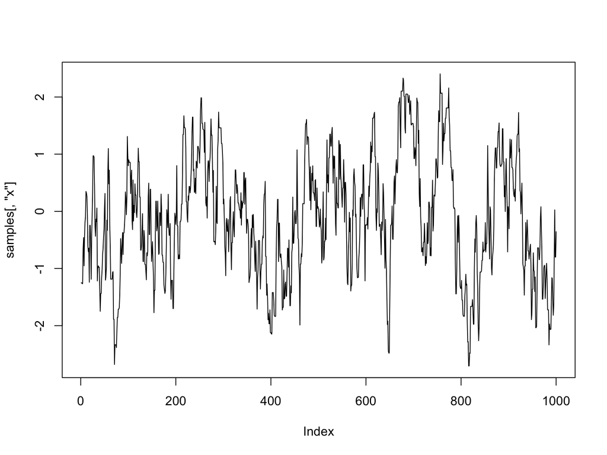

```r
plot(samples[,'x'], type = "l")
```

# Reversible-jump, CAR, BNP

This is a short workshop.

Please see modules 7 and 8 of a recent longer workshop: https://github.com/nimble-training/nimble-virtual-2021.